# Лабораторная работа №7

Операционные системы

Панина Ж. В.

Российский университет дружбы народов, Москва, Россия

26 марта 2025

# Информация

## Докладчик

- Панина Жанна Валерьевна
- НКАбд-02-24, студ. билет № 1132246710
- студент направления “Компьютерные и информационные науки”
- Российский университет дружбы народов
- 1132246710@pfur.ru
- https://github.com/zvpanina/study_2024-2025_os-intro

# Вводная часть

## Актуальность

Изучение файловой системы Linux и команд для работы с ней является важным аспектом подготовки специалистов в области информационных технологий, системного администрирования и DevOps. Современные IT-инфраструктуры часто развертываются на Linux-серверах, и понимание принципов работы файловой системы, управления процессами и обслуживания дискового пространства критически необходимо для эффективного администрирования серверов и оптимизации работы с данными.

## Объект и предмет исследования

### Объект исследования:

Файловая система Linux, её структура и управление процессами.

### Предмет исследования:

Команды для работы с файлами, каталогами, процессами и дисковым пространством в Linux.

## Цели и задачи

Цель работы - ознакомление с файловой системой Linux, её структурой, именами и содержанием каталогов. Приобретение практических навыков по применению команд для работы с файлами и каталогами, по управлению процессами (и работами), по проверке использования диска и обслуживанию файловой системы.

### Задачи:

1. Выполните все примеры, приведённые в первой части описания лабораторной работы.
2. Выполните следующие действия, зафиксировав в отчёте по лабораторной работе используемые при этом команды и результаты их выполнения:
- Скопируйте файл /usr/include/sys/io.h в домашний каталог и назовите его equipment.
- В домашнем каталоге создайте директорию ~/ski.plases.
- Переместите файл equipment в каталог ~/ski.plases.
- Переименуйте файл ~/ski.plases/equipment в ~/ski.plases/equiplist.
- Создайте в домашнем каталоге файл abc1 и скопируйте его в каталог ~/ski.plases, назовите его equiplist2.
- Создайте каталог с именем equipment в каталоге ~/ski.plases.
- Переместите файлы ~/ski.plases/equiplist и equiplist2 в каталог ~/ski.plases/equipment.
- Создайте и переместите каталог ~/newdir в каталог ~/ski.plases и назовите его plans.
3. Определите опции команды chmod, необходимые для того, чтобы присвоить перечисленным ниже файлам выделенные права доступа, считая, что в начале таких прав нет:
- drwxr–r– … australia
- drwx–x–x … play
- -r-xr–r– … my_os
- -rw-rw-r– … feathers При необходимости создайте нужные файлы.
4. Проделайте приведённые ниже упражнения, записывая в отчёт по лабораторной работе используемые при этом команды:
- Просмотрите содержимое файла /etc/password.
- Скопируйте файл ~/feathers в файл ~/file.old.
- Переместите файл ~/file.old в каталог ~/play.
- Скопируйте каталог ~/play в каталог ~/fun.
- Переместите каталог ~/fun в каталог ~/play и назовите его games.
- Лишите владельца файла ~/feathers права на чтение.
- Что произойдёт, если вы попытаетесь просмотреть файл ~/feathers командой cat?
- Что произойдёт, если вы попытаетесь скопировать файл ~/feathers?
- Дайте владельцу файла ~/feathers право на чтение.
- Лишите владельца каталога ~/play права на выполнение.
- Перейдите в каталог ~/play. Что произошло?
- Дайте владельцу каталога ~/play право на выполнение.
5. Прочитайте man по командам mount, fsck, mkfs, kill и кратко их охарактеризуйте, приведя примеры.

## Материалы и методы

### Материалы:

- Операционная система Linux
- Терминал и встроенные утилиты (ls, cd, mkdir, rm, ps, kill, df, du, mount, fsck и др.).
- Документация по командам (man, –help).

### Методы:

- Анализ структуры файловой системы – изучение стандартных каталогов (/bin, /etc, /home, /var и др.).
- Практическое применение команд для:
- Навигации по файловой системе (cd, pwd, ls).
- Управления файлами и каталогами (mkdir, touch, cp, mv, rm).
- Работы с правами доступа (chmod, chown).
- Управления процессами (ps, top, kill, jobs, bg, fg).
- Обслуживания файловой системы (mount, umount, fsck).
- Выполнение заданий, фиксация результатов, анализ ошибок.

# Теоретическое введение

Файловая система в Linux состоит из фалов и каталогов. Каждому физическому носителю соответствует своя файловая система. Существует несколько типов файловых систем. Перечислим наиболее часто встречающиеся типы: - ext2fs (second extended filesystem); - ext2fs (third extended file system); - ext4 (fourth extended file system); - ReiserFS; - xfs; - fat (file allocation table); - ntfs (new technology file system). Для просмотра используемых в операционной системе файловых систем можно воспользоваться командой mount без параметров.

# Выполнение лабораторной работы

1. Выполняю все примеры, приведённые в первой части описания лабораторной работы. Создаю файл abc1, копирую abc1 в april и в may.

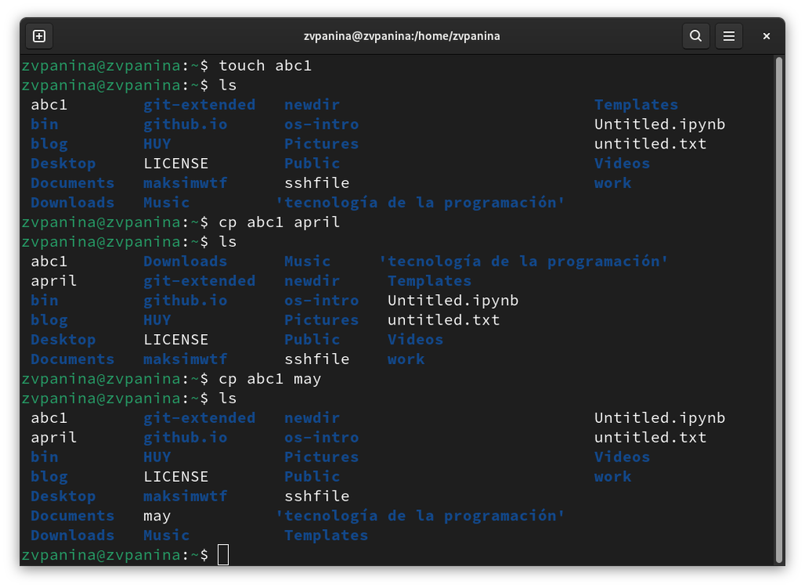

Выполнение примеров

Создаю каталог monthly, копирую april и may в monthly, копирую monthly/may в monthly/june и проверяю содержимое monthly.

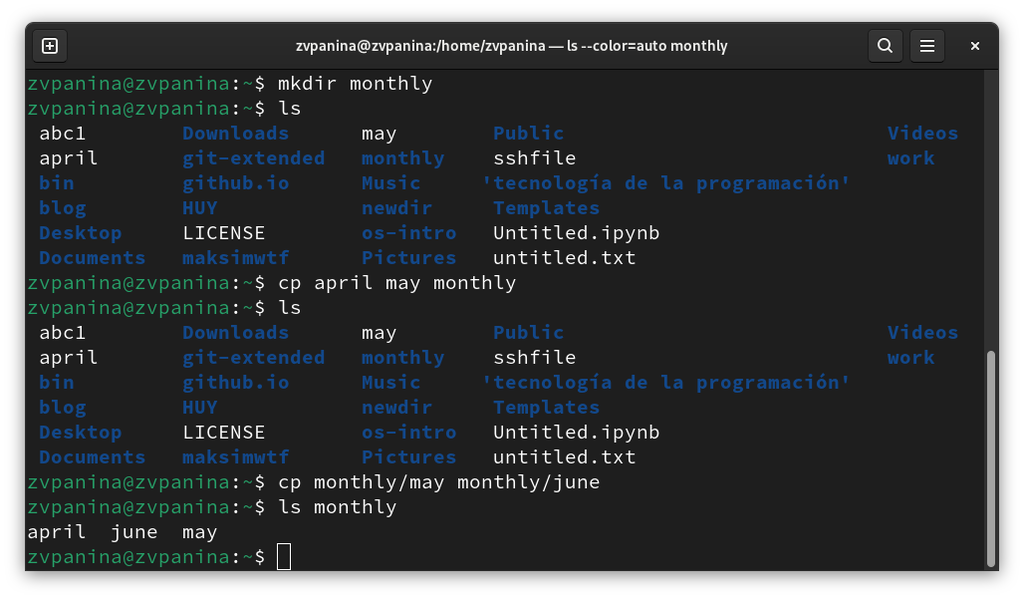

Выполнение примеров

Создаю директорию monthly.00 и рекурсивно копирую в неё monthly, далее копирую monthly.00 в /tmp, проверяю содержимое /tmp.

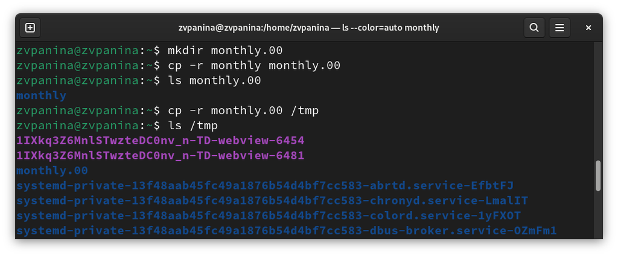

Выполнение примеров

Переименовываю april в july и перемещаю его в monthly.00. Переименовываю monthly.00 в monthly.01, создаю директорию reports. Перемещаю директорию monthly.01 в reports и переименовываю её в monthly, проверяю.

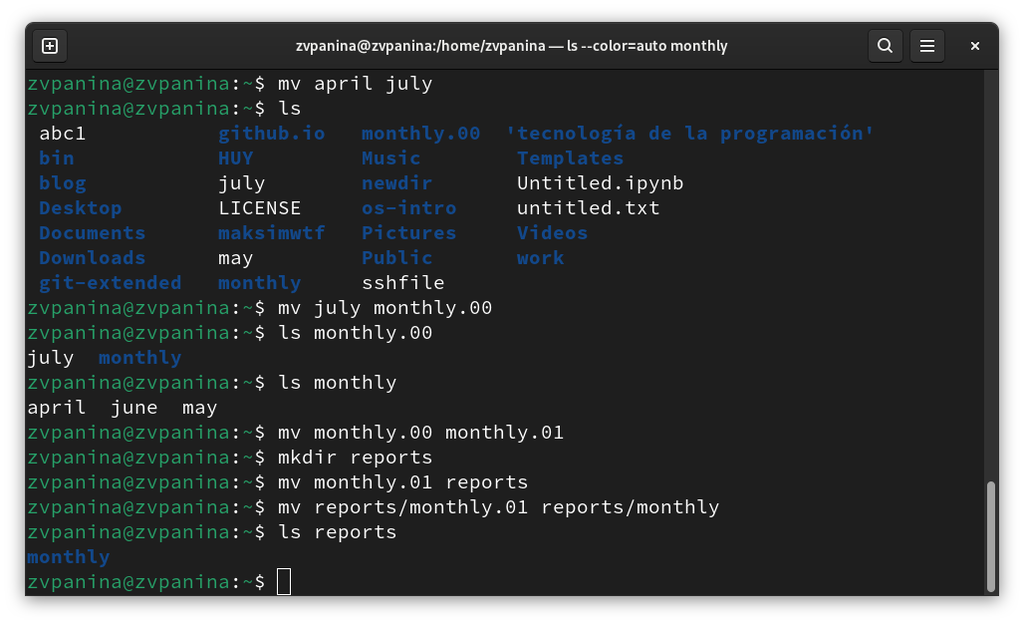

Выполнение примеров

Создаю файл may, проверяю права доступа. Добавляю владельцу право на выполнение файла. Проверяю изменения, потом лишаю владельца права на выполнение, проверяю. Для каталога monthly меняю права доступа: лишаю участников группы и остальных права на чтение.

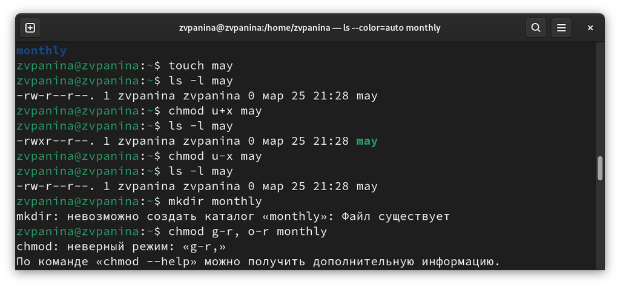

Выполнение примеров

Проверяю права доступа для каталога monthly.

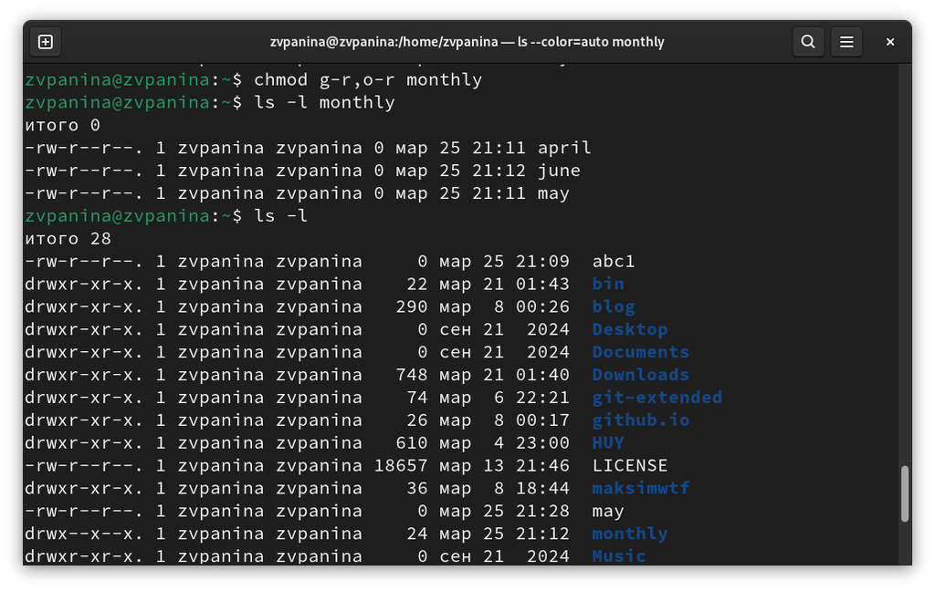

Выполнение примеров

Создаю файл abc1, для него добавляю членам группы право на изменение файла, проверяю.

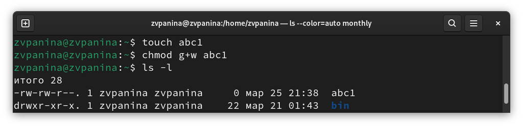

Выполнение примеров

2. Копирую файл /usr/include/sys/io.h в домашний каталог и переименовываю его в equipment.

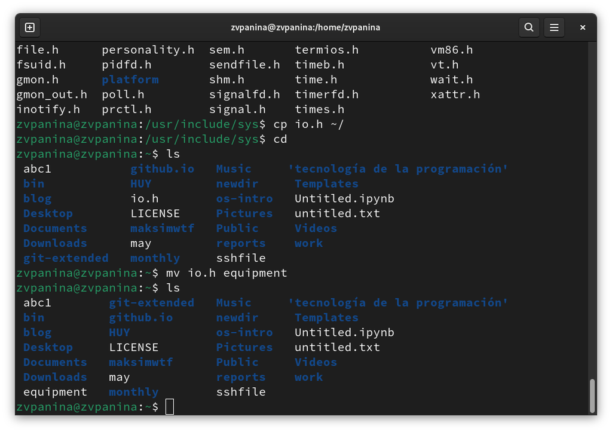

Перемещение io.h в домашний каталог

В домашнем каталоге создаю директорию ~/ski.plases. Перемещаю файл equipment в каталог ~/ski.plases. Переименовываю файл ~/ski.plases/equipment в ~/ski.plases/equiplist. Создаю в домашнем каталоге файл abc1 и копирую его в каталог ~/ski.plases, называю его equiplist2.

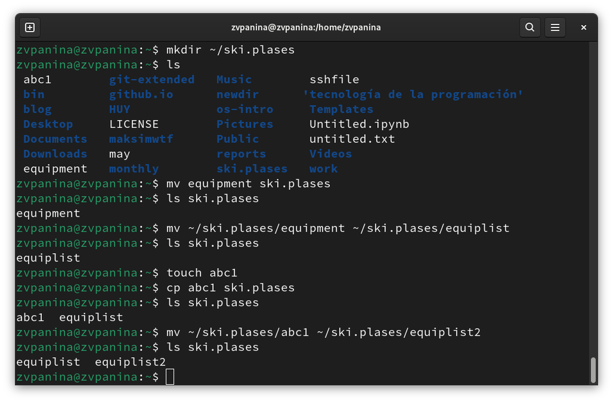

Работа с каталогом ~/ski.plases

Создаю каталог с именем equipment в каталоге ~/ski.plases. Перемещаю файлы ~/ski.plases/equiplist и equiplist2 в каталог ~/ski.plases/equipment. Создаю и перемещаю каталог ~/newdir в каталог ~/ski.plases и называю его plans.

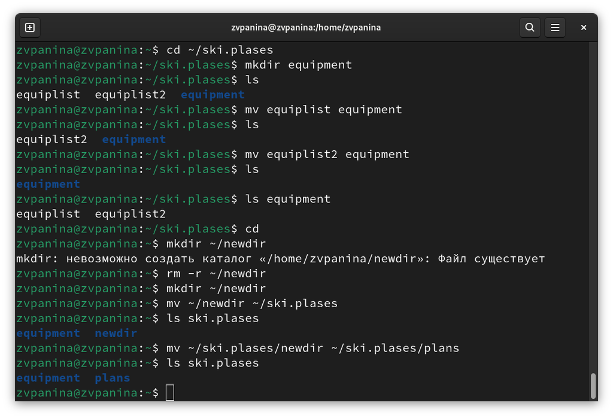

Работа с каталогом ~/ski.plases

3. Создаю необходимые файлы и директории и изменяю права доступа для них.

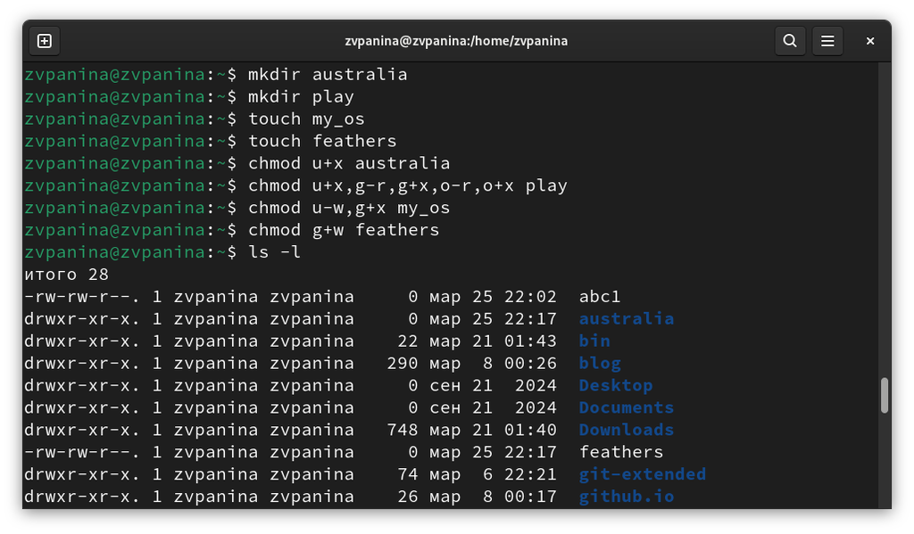

Изменение прав доступа для каталогов australia, play и файлов my_os, features

Для удобства я создала каталог vacation, куда переместила используемые файлы и каталоги, и проверила права доступа к ним. После этого я вернула их обратно в домашнюю папку и удалила каталог vacation.

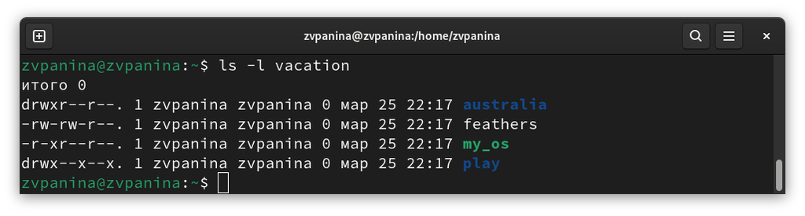

Изменение прав доступа для каталогов australia, play и файлов my_os, features

4. Перехожу в каталог /etc и вижу, что у меня нет файла password. Он называется passwd.

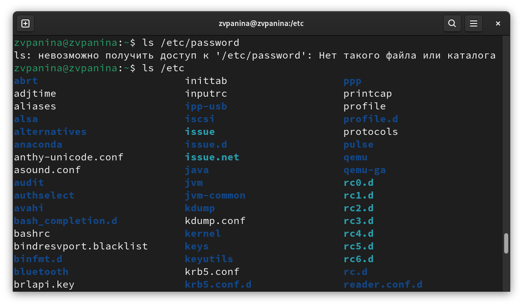

Просмотр содержимого каталога /etc

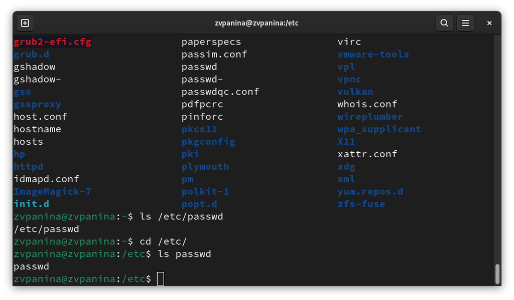

Копирую файл ~/feathers в файл ~/file.old. Перемещаю файл ~/file.old в каталог ~/play. Копирую каталог ~/play в каталог ~/fun, проверяю.

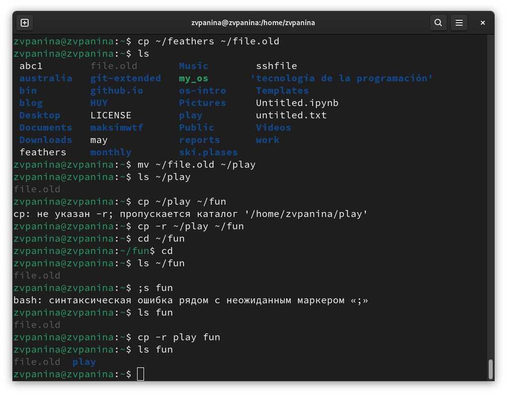

Работа с файлами ~/featers и ~/file.old, каталогами ~/play и ~/fun

Перемещаю каталог ~/fun в каталог ~/play и называю его games. Лишаю владельца файла ~/feathers права на чтение. Пытаюсь просмотреть файл ~/feathers командой cat, мне отказано в доступе, т.к. я только что лишила себя права на чтение. Пытаюсь скопировать файл ~/feathers, например, в ~/play, мне отказано в доступе по той же причине. Снова даю владельцу файла ~/feathers право на чтение. Лишаю владельца каталога ~/play права на выполнение. Перехожу в каталог ~/play. Отказано в доступе, т.к. я лишила себя права на выполнение. Возвращаю владельцу каталога ~/play право на выполнение.

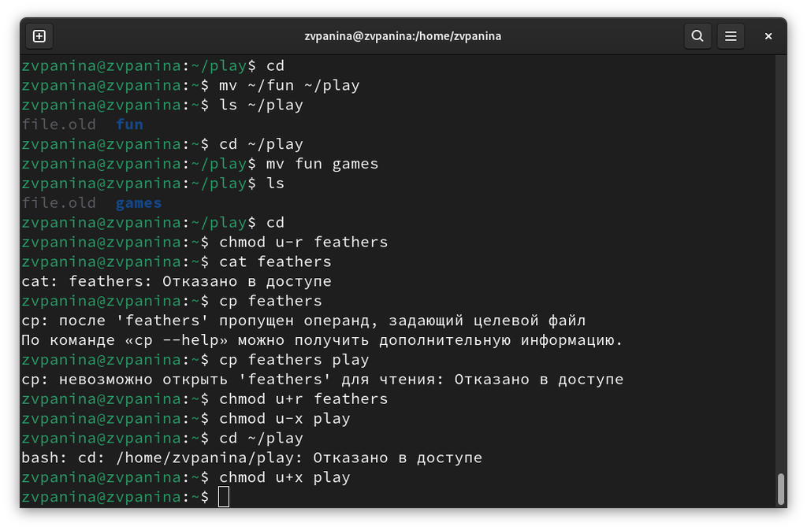

Работа с правами доступа

5. Читаю man по командам:

### mount

Назначение: Подключение файловых систем к указанным точкам монтирования. Ключевые опции: - -t — тип файловой системы (ext4, ntfs, nfs). - -o — дополнительные параметры (например, ro для только чтения);

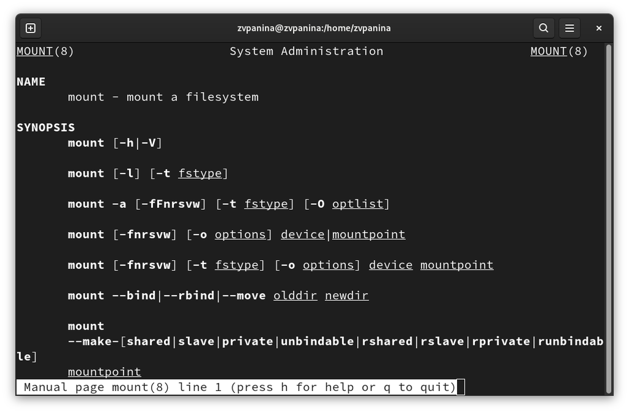

man mount

### fsck

Назначение: Проверка и исправление ошибок файловой системы. Ключевые опции: - -y — автоматическое исправление ошибок. - -f — принудительная проверка. - -C — вывод прогресса;

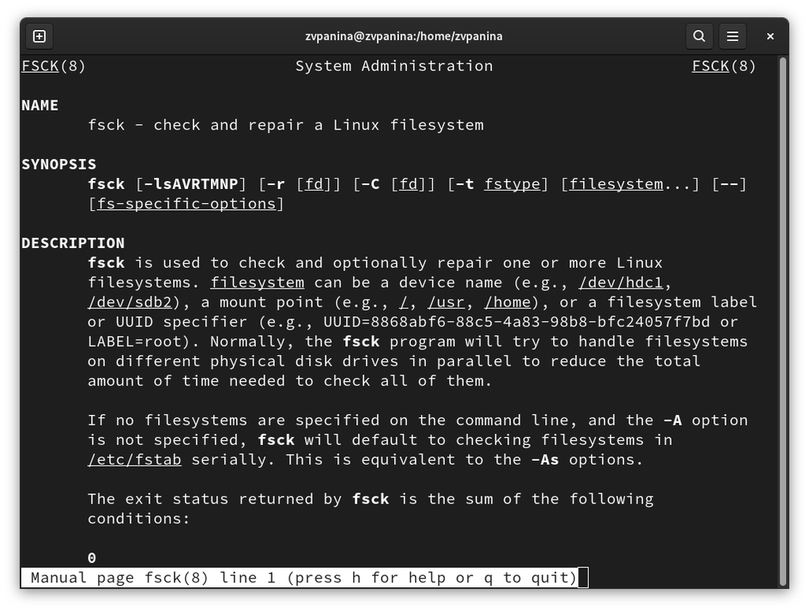

man fsck

### kill

Назначение: Отправка сигналов процессам (по умолчанию — SIGTERM для завершения). Ключевые сигналы: - -9 (SIGKILL) — немедленное завершение. - -15 (SIGTERM) — корректное завершение (по умолчанию). - -1 (SIGHUP) — перезапуск процесса;

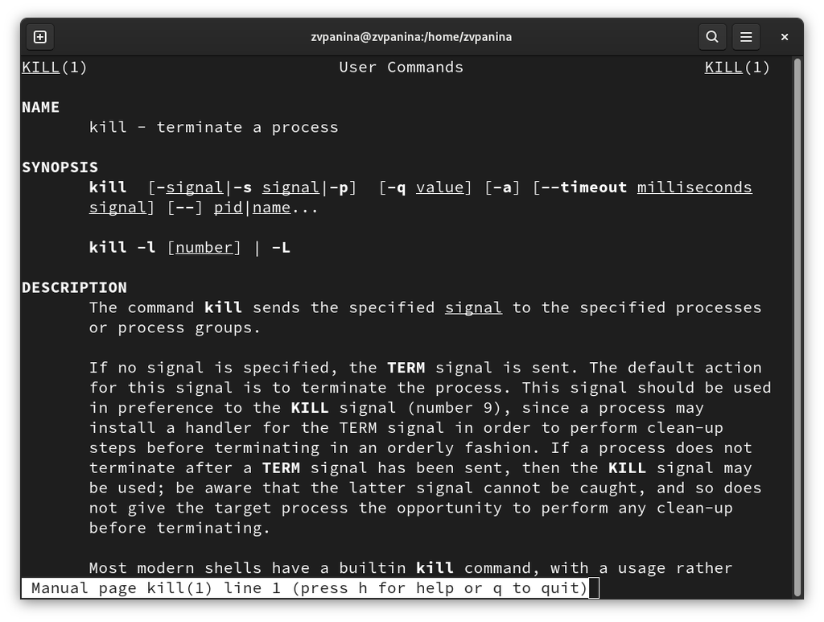

man kill

### mkfs

Назначение: Создание файловой системы на устройстве. Ключевые опции: - -t — тип файловой системы (ext4, xfs, vfat). - -L — задает метку тома.

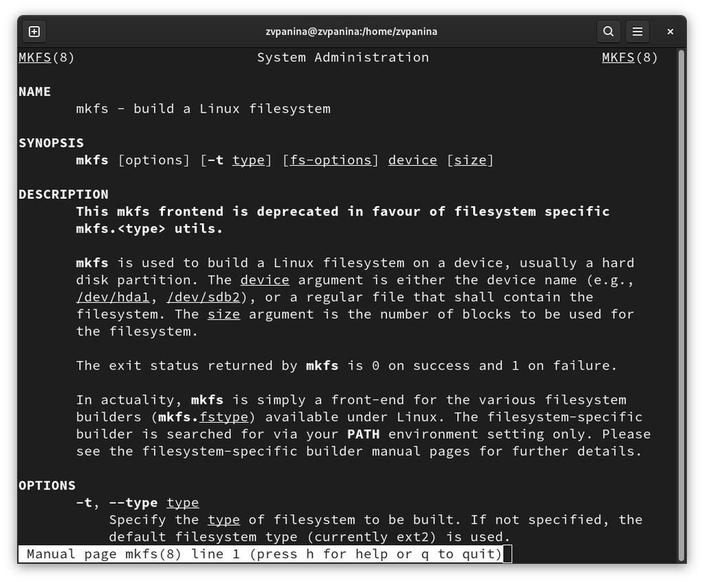

man mkfs